# Genotype plus Genotype-By-Block-of-Environments Biplots

Kevin Wright

2016-11-18

# Abstract

A short note about GGE and GGB biplots.

# R setup

```r
library("knitr")
knitr::opts_chunk$set(fig.align="center", fig.width=6, fig.height=6)
options(width=90)
```

```r
library(agridat)
```

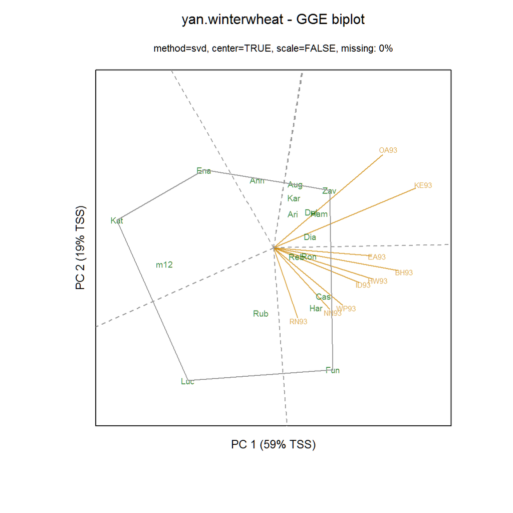

```r
data(yan.winterwheat)
dat1 <- yan.winterwheat

library(gge)
m1 <- gge(yield~gen*env, dat1, scale=FALSE)
biplot(m1, title="yan.winterwheat - GGE biplot",
       flip=c(1,0), origin=0, hull=TRUE)
```

Many people prefer to use ‘standardized’ biplots, in which the data for each environement has been centered and scaled. For standardized biplots, a unit circle is drawn. Environment vectors that reach out to the unit circle are perfectly represented in the two dimensional plane.

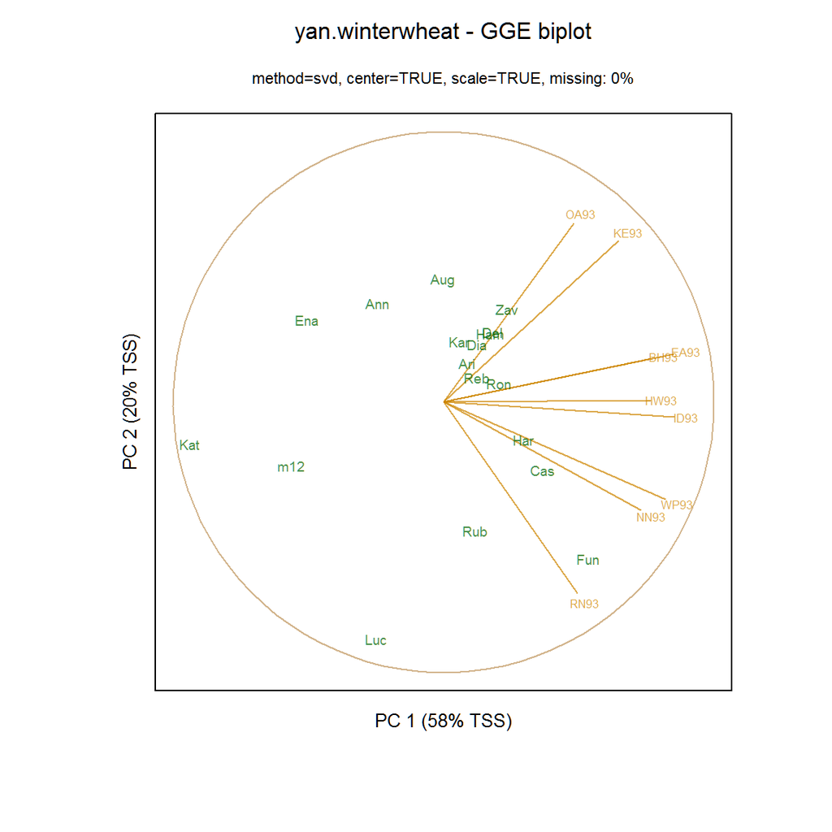

```r
m2 <- gge(yield~gen*env, dat1, scale=TRUE)
biplot(m2, title="yan.winterwheat - GGE biplot",
       flip=c(1,1), origin=0)
```

As seen above, the environment vectors are fairly long, so that relative performance of genotypes in environments can be assessed with reasonable accuracy. In contrast, a biplot based on principal components 2 and 3 has shorter vectors which should not be interpreted.

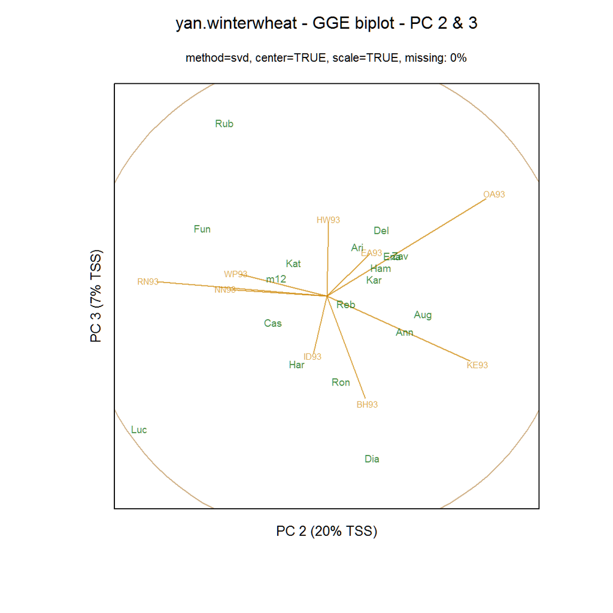

```r
biplot(m2, title="yan.winterwheat - GGE biplot - PC 2 & 3",
       comps=c(2,3), flip=c(1,1), origin=0)
```

Laffont, Hanafi, and Wright (2007) showed how to partition the sums-of-squares simultaneously along the principal component axes and along ‘G’ and ‘GxE’ axes.

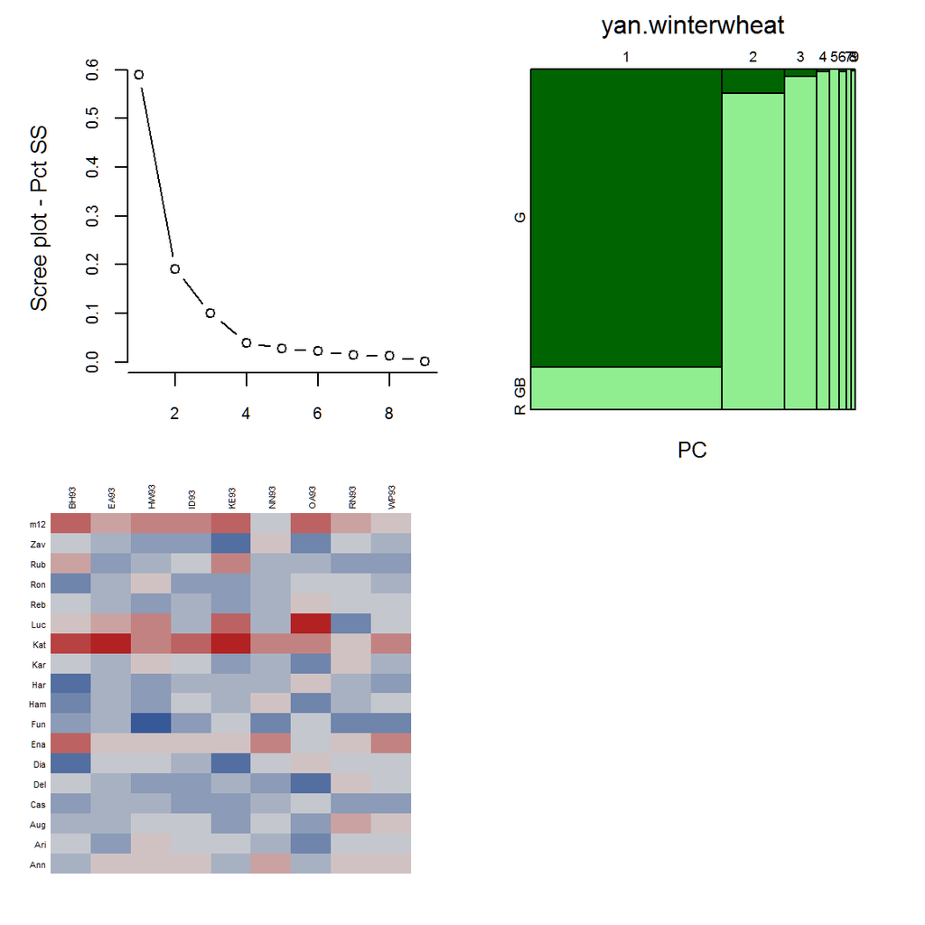

```r
plot(m1, title="yan.winterwheat")
```

The mosaic plot above shows that the first principal component axis is capturing almost all of the variation between genotypes, so that a projection of the genotype markers onto the first principal component axis is a good overall representation of the rankings of the genotypes.

Laffont, Wright, and Hanafi (2013) presented GGB (genotype plus genotype-by-block of environments) biplots, which are useful to enhance the view of mega-environments consisting of multiple locations.

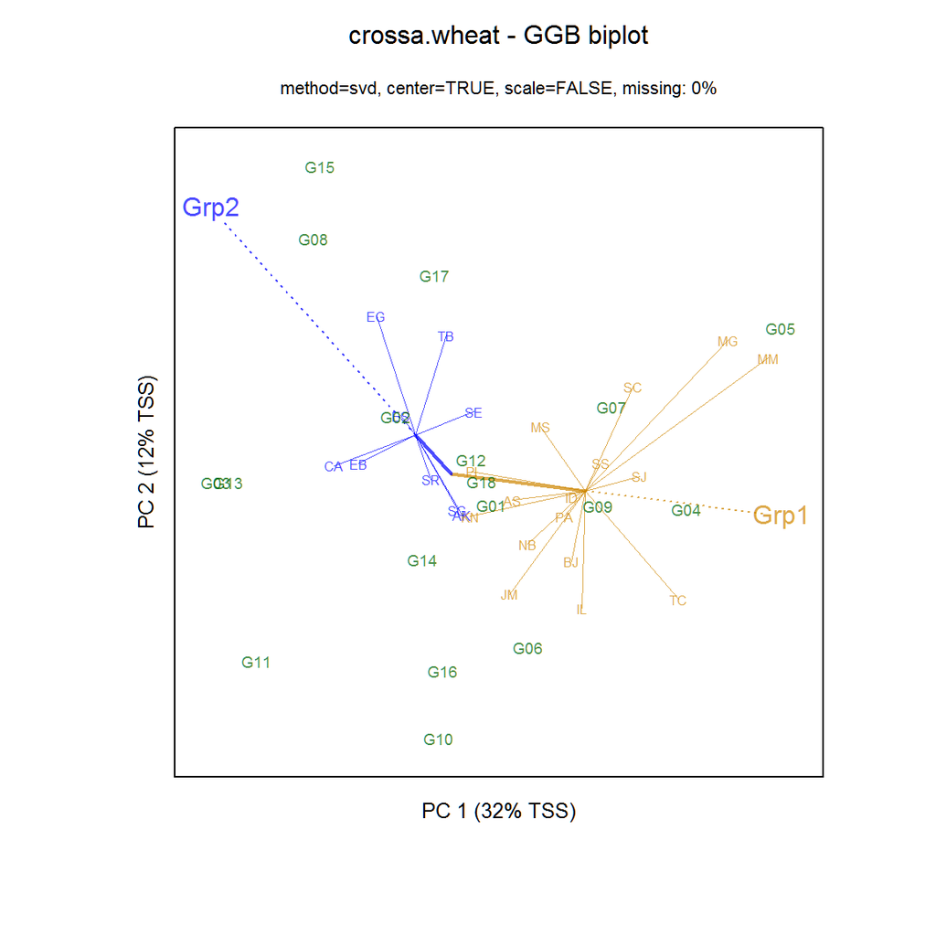

```r
library(agridat)
data(crossa.wheat)
dat2 <- crossa.wheat

# Define mega-environment groups of locations
dat2$eg <- ifelse(is.element(dat2$loc,
                             c("KN","NB","PA","BJ","IL","TC",
                               "JM","PI","AS","ID","SC","SS",
                               "SJ","MS","MG","MM")), "Grp1", "Grp2")

library(gge)
# Specify env.group as column in data frame
m3 <- gge(yield~gen*loc, dat2, env.group=eg, scale=FALSE)
biplot(m3, title="crossa.wheat - GGB biplot")
```

References

Laffont, Jean-Louis, Mohamed Hanafi, and Kevin Wright. 2007. “Numerical and Graphical Measures to Facilitate the Interpretation of GGE Biplots.” *Cs* 47: 990–96. [doi:10.2135/cropsci2006.08.0549](http://doi.org/10.2135/cropsci2006.08.0549).

Laffont, Jean-Louis, Kevin Wright, and Mohamed Hanafi. 2013. “Genotype Plus Genotype-by-Block of Environments Biplots.” *Crop Science* 53 (6): 2332–41. [doi:10.2135/cropsci2013.03.0178](http://doi.org/10.2135/cropsci2013.03.0178).

Yan, Weikai, and Nicholas A Tinker. 2006. “Biplot Analysis of Multi-Environment Trial Data: Principles and Applications.” *Canadian Journal of Plant Science* 86: 623–45. [doi:10.4141/P05-169](http://doi.org/10.4141/P05-169).